# Plomo en sangre y coordinación visomanual en niños

PlomoBot · Reanálisis en R para la lectura crítica del artículo

Autor/a

Fecha de publicación

1 de octubre de 2026

**Artículo:** Squillante G, Rojas M, Medina E, et al. *Gac Méd Caracas*. 2005;113(1):50-57.

Este reporte usa R para comprobar con números cuatro puntos de la lectura crítica: la medida de asociación que faltó, el tamaño muestral, la potencia del estudio y el papel de la edad como confusor.

# Datos publicados

La exposición es el plomo en sangre (Pb-S ≥ 10 vs. < 10 µg/dL) y el desenlace es un resultado inferior en el test de Beery (más de 6 meses por debajo de la edad cronológica). Los datos salen de los Cuadros 1 a 4 del artículo.

**Código**

```r
# Datos publicados en el artículo ------------------------------------------
# Squillante G, Rojas M, Medina E, et al. Gac Méd Caracas. 2005;113(1):50-57
# Texto completo: https://ve.scielo.org/scielo.php?script=sci_arttext&pid=S0367-47622005000100005

# Cuadro 2: plomo en sangre (Pb-S) según resultado del test de Beery.
# Filas = exposición (expuestos primero), columnas = desenlace (casos primero).
# Este orden es el que espera epiR::epi.2by2().
tabla <- matrix(
  c(29, 8,    # Pb-S >= 10 µg/dL: 29 con Beery inferior de 37
    19, 4),   # Pb-S <  10 µg/dL: 19 con Beery inferior de 23
  nrow = 2, byrow = TRUE,
  dimnames = list(
    Plomo = c("Pb-S >= 10", "Pb-S < 10"),
    Beery = c("Inferior", "No inferior")
  )
)
tabla
```

```
            Beery
Plomo        Inferior No inferior
  Pb-S >= 10       29           8
  Pb-S < 10        19           4
```

**Código**

```r
addmargins(tabla)
```

```
            Beery
Plomo        Inferior No inferior Sum
  Pb-S >= 10       29           8  37
  Pb-S < 10        19           4  23
  Sum              48          12  60
```

**Código**

```r
# Cuadro 2 (medias de Pb-S en µg/dL): lo que compararon los autores con t de Student
pb_segun_beery <- data.frame(
  grupo = c("Inferior", "Normal"),
  n     = c(48, 12),
  media = c(10.54, 10.3),
  de    = c(3, 2.9)
)
pb_segun_exposicion <- data.frame(
  grupo = c("Pb-S >= 10", "Pb-S < 10"),
  n     = c(37, 23),
  media = c(12.3, 7.5),
  de    = c(2.2, 1.3)
)

# Cuadros 1 y 4: Pb-S y Beery según sexo
por_sexo <- data.frame(
  sexo           = c("Masculino", "Femenino"),
  n              = c(35, 25),
  pb_media       = c(11.1, 9.5),
  pb_de          = c(3.1, 2.7),
  beery_inferior = c(27, 21)
)

# Cuadros 1 y 3: Pb-S y Beery según edad
por_edad <- data.frame(
  edad           = c("4-5,9", "6-7,9", "8-9"),
  n              = c(7, 21, 32),
  pb_media       = c(11.1, 11.2, 9.8),
  pb_de          = c(2.4, 3.5, 2.6),  # el Cuadro 1 dice "22,6" para 8-9: errata, se asume 2,6
  beery_inferior = c(2, 15, 31)
)
por_edad
```

```
   edad  n pb_media pb_de beery_inferior
1 4-5,9  7     11.1   2.4              2
2 6-7,9 21     11.2   3.5             15
3   8-9 32      9.8   2.6             31
```

# Parte 1. El análisis que correspondía

Los autores compararon la **media de plomo** entre los grupos de Beery con una t de Student. Es decir, trataron el desenlace como si fuera la causa. En un estudio transversal analítico lo que corresponde es comparar la **prevalencia del desenlace según la exposición** y reportar una medida de asociación con su intervalo de confianza.

**Código**

```r
# Parte 1. El análisis que correspondía -------------------------------------
# Comparar el desenlace (Beery inferior) según la exposición (plomo),
# con una medida de asociación y su intervalo de confianza.

library(epiR)
library(ggplot2)

# Lo que hicieron los autores: t de Student con las medias del Cuadro 2 ------
# Se puede reproducir con los resúmenes publicados (media, DE, n).
t_resumen <- function(d) {
  sp <- sqrt(((d$n[1] - 1) * d$de[1]^2 + (d$n[2] - 1) * d$de[2]^2) / (sum(d$n) - 2))
  t  <- (d$media[1] - d$media[2]) / (sp * sqrt(1 / d$n[1] + 1 / d$n[2]))
  c(t = t, gl = sum(d$n) - 2, p = 2 * pt(-abs(t), sum(d$n) - 2))
}

# Pb-S según Beery (reportan P = 0,834): la exposición tratada como desenlace
t_beery <- t_resumen(pb_segun_beery)
t_beery
```

```
         t         gl          p
 0.2494263 58.0000000  0.8039123
```

**Código**

```r
# Pb-S según Pb-S >= 10 vs. < 10 (reportan P = 0,001): los grupos se definen
# por el propio plomo, así que la diferencia es obligatoria y no informa nada
t_circular <- t_resumen(pb_segun_exposicion)
t_circular
```

```
           t           gl            p
9.468286e+00 5.800000e+01 2.258943e-13
```

**Código**

```r
# Pb-S según sexo (reportan P = 0,042)
t_sexo <- t_resumen(setNames(por_sexo[, c("sexo", "n", "pb_media", "pb_de")],
                             c("grupo", "n", "media", "de")))
t_sexo
```

```
          t          gl           p
 2.07749664 58.00000000  0.04219319
```

**Código**

```r
# Razón de prevalencias (RP) y razón de odds (OR) con IC 95 %
res_2x2 <- epi.2by2(tabla, method = "cross.sectional", conf.level = 0.95)
res_2x2
```

```
             Outcome +    Outcome -      Total               Prev risk *
Exposed +           29            8         37    78.38 (61.79 to 90.17)
Exposed -           19            4         23    82.61 (61.22 to 95.05)
Total               48           12         60    80.00 (67.67 to 89.22)

Point estimates and 95% CIs:
-------------------------------------------------------------------
Prev risk ratio                                0.95 (0.74, 1.22)
Prev odds ratio                                0.76 (0.20, 2.89)
Attrib prev in the exposed *                   -4.23 (-24.62, 16.16)
Attrib fraction in the exposed (%)            -5.40 (-35.68, 18.13)
Attrib prev in the population *                -2.61 (-21.11, 15.90)
Attrib fraction in the population (%)         -3.26 (-20.30, 11.37)
-------------------------------------------------------------------
Yates corrected chi2 test that OR = 1: chi2(1) = 0.004 Pr>chi2 = 0.947
Fisher exact test that OR = 1: Pr>chi2 = 0.752
 Wald confidence limits
 CI: confidence interval
 * Outcomes per 100 population units
```

**Código**

```r
medidas <- res_2x2$massoc.summary
rp <- medidas[medidas$var %in% c("Prev risk ratio", "Prev ratio"), c("est", "lower", "upper")]
or <- medidas[medidas$var %in% c("Prev odds ratio", "Odds ratio"), c("est", "lower", "upper")]

# Prueba de hipótesis. Una frecuencia esperada es < 5 (celda <10 / no inferior),
# por eso se prefiere la exacta de Fisher sobre chi-cuadrado.
chisq.test(tabla)$expected
```

```
            Beery
Plomo        Inferior No inferior
  Pb-S >= 10     29.6         7.4
  Pb-S < 10      18.4         4.6
```

**Código**

```r
prueba_fisher <- fisher.test(tabla)
prueba_fisher
```

```
    Fisher's Exact Test for Count Data

data:  tabla
p-value = 0.7524
alternative hypothesis: true odds ratio is not equal to 1
95 percent confidence interval:
 0.1476496 3.3678686
sample estimates:
odds ratio
 0.7665369
```

**Código**

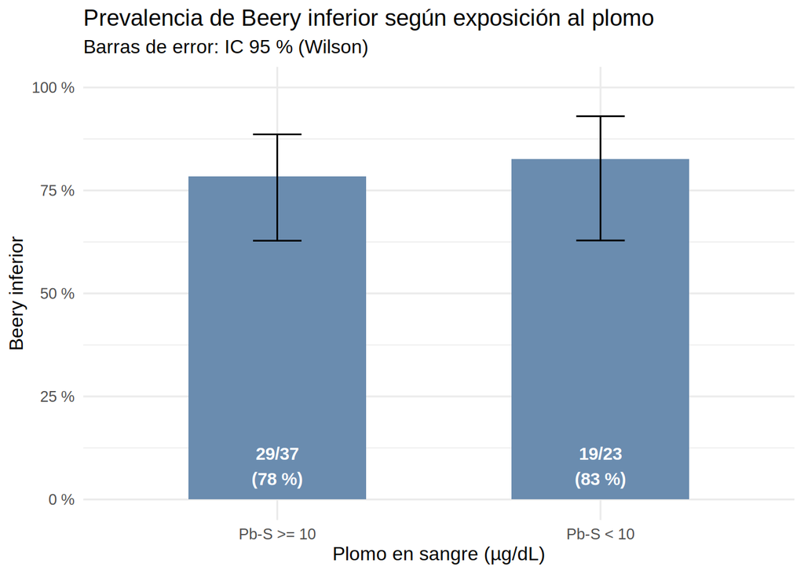

```r
# Gráfico: proporción de Beery inferior por grupo de plomo, con IC 95 % (Wilson)
prop_grupo <- data.frame(
  plomo = factor(rownames(tabla), levels = rownames(tabla)),
  casos = tabla[, "Inferior"],
  n     = rowSums(tabla)
)
ic <- t(mapply(function(x, n) prop.test(x, n, correct = FALSE)$conf.int,
               prop_grupo$casos, prop_grupo$n))
prop_grupo$p     <- prop_grupo$casos / prop_grupo$n
prop_grupo$lower <- ic[, 1]
prop_grupo$upper <- ic[, 2]

grafico_proporciones <- ggplot(prop_grupo, aes(plomo, p)) +
  geom_col(fill = "#6a8caf", width = 0.55) +
  geom_errorbar(aes(ymin = lower, ymax = upper), width = 0.15) +
  geom_text(aes(label = sprintf("%d/%d\n(%.0f %%)", casos, n, 100 * p)),
            y = 0.08, colour = "white", fontface = "bold") +
  scale_y_continuous(labels = function(x) paste0(100 * x, " %"),
                     limits = c(0, 1)) +
  labs(x = "Plomo en sangre (µg/dL)", y = "Beery inferior",
       title = "Prevalencia de Beery inferior según exposición al plomo",
       subtitle = "Barras de error: IC 95 % (Wilson)") +
  theme_minimal(base_size = 12)
grafico_proporciones
```

**Código**

```r
# Sexo: la discusión dice que los varones tienen más Beery inferior porque
# son 27 vs. 21 niñas. Pero hay más varones (35 vs. 25): hay que comparar
# proporciones, no conteos.
tabla_sexo <- matrix(
  c(por_sexo$beery_inferior, por_sexo$n - por_sexo$beery_inferior),
  nrow = 2, dimnames = list(Sexo = por_sexo$sexo, Beery = c("Inferior", "No inferior"))
)
tabla_sexo
```

```
           Beery
Sexo        Inferior No inferior
  Masculino       27           8
  Femenino        21           4
```

**Código**

```r
prop_sexo <- por_sexo$beery_inferior / por_sexo$n
names(prop_sexo) <- por_sexo$sexo
round(100 * prop_sexo, 1)
```

```
Masculino  Femenino
     77.1      84.0
```

**Código**

```r
rp_sexo <- unname(prop_sexo[1] / prop_sexo[2])
rp_sexo
```

```
[1] 0.9183673
```

**Código**

```r
fisher_sexo <- fisher.test(tabla_sexo)
fisher_sexo$p.value
```

```
[1] 0.7446875
```

**Lo que hicieron los autores, reproducido.** Con las medias, DE y n del Cuadro 2, la t de Student de Pb-S entre los grupos de Beery da p = 0,80 (reportan 0,834; la diferencia viene del redondeo de las DE). La diferencia de Pb-S por sexo da p = 0,042, igual a la publicada. El “P = 0,001” que destacan compara la media de Pb-S entre niños con Pb-S ≥ 10 y < 10. Como los grupos se definen por el propio plomo, la diferencia es obligatoria y no dice nada sobre el Beery.

**Interpretación.** La razón de prevalencias es RP = 0,95 (IC 95 %: 0,74–1,22). El intervalo incluye el 1, y la prueba exacta de Fisher da p = 0,75. En el análisis crudo no hay asociación entre el plomo y el Beery inferior. La razón de odds (OR = 0,76) se aleja más del 1 que la RP porque el desenlace es muy frecuente (80 %). En ese caso la OR exagera la magnitud del efecto y es preferible reportar la RP.

**Sexo.** En la discusión, los autores dicen que los varones tienen más Beery inferior porque son 27 contra 21 niñas. Pero comparan conteos, y había más varones (35 vs. 25). En proporciones es al revés: 77,1 % en varones vs. 84,0 % en niñas (RP = 0,92; Fisher p = 0,74).

# Parte 2. Tamaño muestral y potencia

Los autores usaron la fórmula para **estimar una proporción**, pero su pregunta exigía **comparar dos proporciones**.

**Código**

```r
# Parte 2. Tamaño muestral y potencia ---------------------------------------

library(epiR)
library(pwr)
library(ggplot2)

z_alfa <- qnorm(1 - 0.05 / 2)  # 1,96
z_beta <- qnorm(0.80)          # 0,84

# Lo que hicieron los autores: fórmula para ESTIMAR una proporción
p <- 0.5; d <- 0.10; N <- 156
n0_autores <- z_alfa^2 * p * (1 - p) / d^2         # ~96
n_autores  <- ceiling(n0_autores / (1 + (n0_autores - 1) / N))  # corrección por población finita
c(n0 = n0_autores, n_corregido = n_autores)
```

```
         n0 n_corregido
   96.03647    60.00000
```

**Código**

```r
# Comprobación con epiR (error relativo 20 % de p = 0,5 equivale a d = 10 %)
epi.sssimpleestb(N = N, Py = p, epsilon = d / p, error = "relative",
                 se = 1, sp = 1, nfractional = FALSE, conf.level = 0.95)
```

```
[1] 60
```

**Código**

```r
# Lo que correspondía: fórmula para COMPARAR dos proporciones
# p1 = Beery inferior esperado en expuestos, p0 = en no expuestos.
# Diferencia mínima que interesa detectar: 80 % vs. 60 % (RP = 1,33).
# ESCENARIO DE EJEMPLO: no viene del artículo. En un estudio real, p0 sale de
# la literatura o de un piloto, y p1 de la diferencia clínicamente relevante.
p1 <- 0.80; p0 <- 0.60
p_barra <- (p1 + p0) / 2
n_grupo <- (z_alfa * sqrt(2 * p_barra * (1 - p_barra)) +
            z_beta * sqrt(p1 * (1 - p1) + p0 * (1 - p0)))^2 / (p1 - p0)^2
n_grupo <- ceiling(n_grupo)  # ~82 por grupo
c(por_grupo = n_grupo, total = 2 * n_grupo)
```

```
por_grupo     total
       82       164
```

**Código**

```r
# Comprobación con R base (n = número por grupo)
power.prop.test(p1 = p1, p2 = p0, sig.level = 0.05, power = 0.80)
```

```
     Two-sample comparison of proportions power calculation

              n = 81.22424
             p1 = 0.8
             p2 = 0.6
      sig.level = 0.05
          power = 0.8
    alternative = two.sided

NOTE: n is number in *each* group
```

**Código**

```r
# Grupos desiguales: k = no expuestos por cada expuesto (en el estudio, 23/37).
# p_barra pasa a ser el promedio ponderado por el tamaño de cada grupo.
k <- 23 / 37
p_barra_k <- (p1 + k * p0) / (1 + k)
n_exp_k <- (z_alfa * sqrt((1 + 1 / k) * p_barra_k * (1 - p_barra_k)) +
            z_beta * sqrt(p1 * (1 - p1) + p0 * (1 - p0) / k))^2 / (p1 - p0)^2
n_exp_k   <- ceiling(n_exp_k)
n_noexp_k <- ceiling(k * n_exp_k)
c(expuestos = n_exp_k, no_expuestos = n_noexp_k, total = n_exp_k + n_noexp_k)
```

```
   expuestos no_expuestos        total
         104           65          169
```

**Código**

```r
# Si se hubiera usado el puntaje continuo del Beery (edad equivalente) en vez
# de dicotomizarlo: fórmula de diferencia de medias. El artículo no reporta la
# DE del puntaje, así que se expresa en unidades de DE (d de Cohen = Δ / σ).
d_cohen <- 0.5   # diferencia "moderada" entre expuestos y no expuestos
n_grupo_continuo <- ceiling(2 * (z_alfa + z_beta)^2 / d_cohen^2)  # ~63 por grupo
c(por_grupo = n_grupo_continuo, total = 2 * n_grupo_continuo)
```

```
por_grupo     total
       63       126
```

**Código**

```r
power.t.test(delta = d_cohen, sd = 1, sig.level = 0.05, power = 0.80)
```

```
     Two-sample t test power calculation

              n = 63.76576
          delta = 0.5
             sd = 1
      sig.level = 0.05
          power = 0.8
    alternative = two.sided

NOTE: n is number in *each* group
```

**Código**

```r
# Potencia real del estudio con los grupos que tuvo (37 expuestos, 23 no)
n_exp <- 37; n_noexp <- 23
p_noexp <- 19 / 23   # prevalencia observada en no expuestos

potencia_escenario <- pwr.2p2n.test(h = ES.h(p1, p0), n1 = n_exp, n2 = n_noexp,
                                    sig.level = 0.05)$power
potencia_observada <- pwr.2p2n.test(h = ES.h(29 / 37, p_noexp), n1 = n_exp,
                                    n2 = n_noexp, sig.level = 0.05)$power
c(escenario_80_vs_60 = potencia_escenario, diferencia_observada = potencia_observada)
```

```
  escenario_80_vs_60 diferencia_observada
          0.38421055           0.06876601
```

**Código**

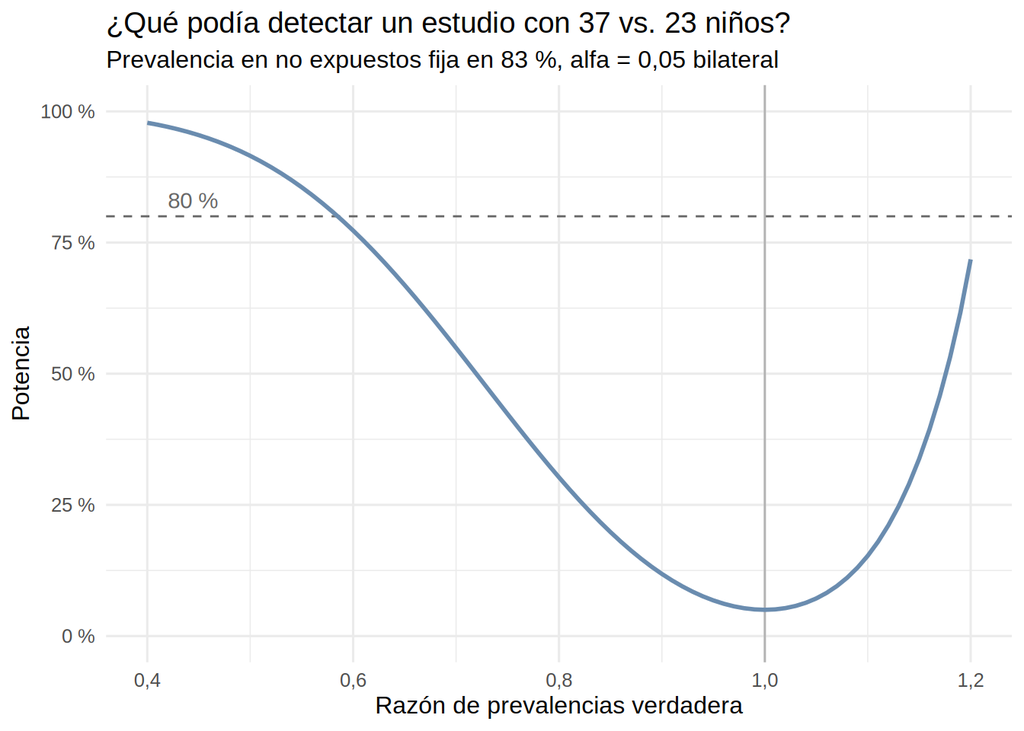

```r
# Curva de potencia: probabilidad de detectar cada RP verdadera
curva <- data.frame(rp = seq(0.40, 1.20, by = 0.01))
curva$p_exp <- pmin(curva$rp * p_noexp, 0.999)
curva$potencia <- sapply(curva$p_exp, function(pe)
  pwr.2p2n.test(h = ES.h(pe, p_noexp), n1 = n_exp, n2 = n_noexp,
                sig.level = 0.05)$power)
curva <- curva[curva$rp * p_noexp < 1, ]

grafico_potencia <- ggplot(curva, aes(rp, potencia)) +
  geom_hline(yintercept = 0.80, linetype = "dashed", colour = "grey40") +
  geom_vline(xintercept = 1, colour = "grey70") +
  geom_line(linewidth = 1, colour = "#6a8caf") +
  annotate("text", x = 0.42, y = 0.83, label = "80 %", hjust = 0, colour = "grey40") +
  scale_y_continuous(labels = function(x) paste0(100 * x, " %"), limits = c(0, 1)) +
  scale_x_continuous(labels = function(x) format(x, decimal.mark = ",")) +
  labs(x = "Razón de prevalencias verdadera", y = "Potencia",
       title = "¿Qué podía detectar un estudio con 37 vs. 23 niños?",
       subtitle = sprintf("Prevalencia en no expuestos fija en %.0f %%, alfa = 0,05 bilateral",
                          100 * p_noexp)) +
  theme_minimal(base_size = 12)
grafico_potencia
```

**Código**

```r
# RP detectables con 80 % de potencia (por debajo y por encima de 1)
rp_detectable_menor <- max(curva$rp[curva$rp < 1 & curva$potencia >= 0.80])
potencia_max_mayor  <- max(curva$potencia[curva$rp > 1])
c(rp_detectable_menor = rp_detectable_menor, potencia_max_si_rp_mayor_1 = potencia_max_mayor)
```

```
       rp_detectable_menor potencia_max_si_rp_mayor_1
                 0.5800000                  0.7179569
```

**Interpretación.**

- Con su fórmula se llega a 60 niños, exactamente su muestra, así que casi seguro fue la que usaron. Esa fórmula responde “¿qué proporción de niños tiene X?”, no “¿difieren dos grupos?”.
- Para el cálculo correcto hay que fijar de antemano la diferencia que se quiere detectar. El artículo no la da, así que usamos un **escenario de ejemplo**: 80 % de Beery inferior en expuestos vs. 60 % en no expuestos (RP ≈ 1,33; α = 0,05; potencia 80 %). En un estudio real estos valores salen de la literatura o de un piloto. Es una diferencia grande, fácil de detectar, y aun así hacían falta 82 por grupo (164 en total), más que los 156 niños disponibles.
- Con grupos desiguales como los del estudio (23 no expuestos por cada 37 expuestos) se necesitan todavía más: 104 expuestos y 65 no expuestos (169 en total).
- Con 37 expuestos y 23 no expuestos, la potencia para detectar una diferencia de 80 % vs. 60 % era de solo 38 %. Para la diferencia que observaron (78 % vs. 83 %) era de 7 %.
- Si hubieran usado el puntaje continuo del Beery en vez de dicotomizarlo, para detectar una diferencia moderada (d de Cohen = 0,5) bastaban 63 niños por grupo, menos que los 82 que exige la comparación de proporciones. Dicotomizar pierde información y potencia. El artículo no reporta la DE del puntaje, así que este cálculo se expresa en unidades de DE.
- El estudio solo alcanzaba un 80 % de potencia para efectos protectores muy grandes (RP ≤ 0,58). Para cualquier efecto dañino (RP > 1) la potencia nunca llega al 80 %, porque la prevalencia en los no expuestos ya es del 83 % y no hay margen para subir. Que el resultado “no sea significativo” dice poco: el estudio casi no podía encontrar nada.

# Parte 3. La edad como confusor (simulación)

**Datos simulados**

El artículo publica el plomo por edad (Cuadro 1) y el Beery por edad (Cuadro 3), pero no la tabla cruzada plomo × edad × Beery. Por eso esta parte **no reanaliza los datos individuales**. Se simula una población con los números de esos cuadros, suponiendo que el Pb-S es normal dentro de cada edad y que el efecto del plomo es el mismo en todas las edades.

La edad cumple las condiciones de un confusor. Se asocia con la exposición: el Pb-S medio es 11,1 y 11,2 µg/dL en los menores y 9,8 µg/dL en los de 8–9 años (Cuadro 1). También se asocia con el desenlace: el Beery inferior sube de 29 % en 4–5 años a 71 % en 6–7 y 97 % en 8–9 (Cuadro 3). Y no es consecuencia del plomo.

**Código**

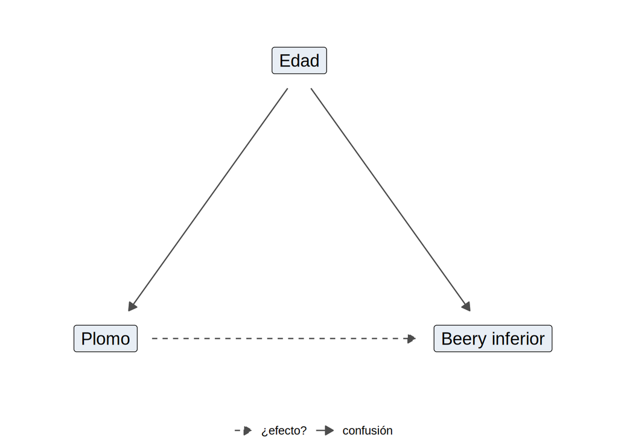

```r
# Parte 3. Simulación: ¿pudo la edad esconder un efecto del plomo? ----------
#
# IMPORTANTE: son DATOS SIMULADOS. El artículo publica plomo x edad (Cuadro 1)
# y Beery x edad (Cuadro 3), pero no la tabla cruzada plomo x edad x Beery,
# así que no se puede reanalizar con los datos individuales. La simulación
# usa los cuadros publicados para ilustrar cómo la edad PODRÍA sesgar la RP.

library(ggplot2)
library(sandwich)
library(lmtest)

# 1. DAG: la edad es causa común de la exposición y del desenlace ----------
nodos <- data.frame(
  nombre = c("Edad", "Plomo", "Beery inferior"),
  x = c(0.5, 0, 1), y = c(1, 0, 0)
)
flechas <- data.frame(
  x    = c(0.47, 0.53, 0.12),  y    = c(0.90, 0.90, 0),
  xend = c(0.06, 0.94, 0.80),  yend = c(0.10, 0.10, 0),
  tipo = c("confusión", "confusión", "¿efecto?")
)
grafico_dag <- ggplot() +
  geom_segment(data = flechas,
               aes(x, y, xend = xend, yend = yend, linetype = tipo),
               arrow = arrow(length = unit(0.25, "cm"), type = "closed"),
               colour = "grey30") +
  geom_label(data = nodos, aes(x, y, label = nombre), size = 5,
             label.padding = unit(0.4, "lines"), fill = "#e8eef5") +
  scale_linetype_manual(values = c("confusión" = "solid", "¿efecto?" = "dashed"),
                        name = NULL) +
  coord_cartesian(xlim = c(-0.2, 1.25), ylim = c(-0.2, 1.15)) +
  theme_void(base_size = 12) +
  theme(legend.position = "bottom")
grafico_dag
```

**Código**

```r
# 2. Parámetros tomados del artículo ----------------------------------------
# `por_edad` viene de 01_datos.R (Cuadros 1 y 3).
#
# SUPUESTO 1: dentro de cada grupo de edad, el Pb-S sigue una distribución
# normal con la media y la DE del Cuadro 1. De ahí sale la proporción de
# niños con Pb-S >= 10 en cada edad.
# SUPUESTO 2: el efecto del plomo (or_verdadero) es igual en todas las edades.
or_verdadero <- 2.5  # escenario: efecto REAL del plomo dentro de cada edad

# Proporción de Beery inferior en no expuestos de cada edad, elegida para que
# la prevalencia total por edad coincida con el Cuadro 3
beery_basal <- function(p_exp, prevalencia, or) {
  plogis(uniroot(function(q) (1 - p_exp) * plogis(q) +
                   p_exp * plogis(q + log(or)) - prevalencia,
                 c(-10, 10))$root)
}

armar_parametros <- function(or) {
  data.frame(
    edad          = por_edad$edad,
    n             = por_edad$n,
    p_expuesto    = 1 - pnorm(10, por_edad$pb_media, por_edad$pb_de),
    p_beery_noexp = mapply(beery_basal,
                           1 - pnorm(10, por_edad$pb_media, por_edad$pb_de),
                           por_edad$beery_inferior / por_edad$n,
                           MoreArgs = list(or = or))
  )
}
parametros <- armar_parametros(or_verdadero)
parametros
```

```
   edad  n p_expuesto p_beery_noexp
1 4-5,9  7  0.6766435     0.1711469
2 6-7,9 21  0.6341470     0.5927348
3   8-9 32  0.4693424     0.9568006
```

**Código**

```r
# Con estos supuestos se esperan ~33 expuestos (en el estudio hubo 37)
sum(parametros$n * parametros$p_expuesto)
```

```
[1] 33.07255
```

**Código**

```r
simular_estudio <- function(par = parametros, or = or_verdadero) {
  edad <- rep(par$edad, par$n)
  i    <- match(edad, par$edad)
  plomo <- rbinom(length(edad), 1, par$p_expuesto[i])
  logit_p <- qlogis(par$p_beery_noexp[i]) + log(or) * plomo
  beery <- rbinom(length(edad), 1, plogis(logit_p))
  data.frame(edad = factor(edad, levels = par$edad), plomo, beery)
}

# RP cruda y RP de Mantel-Haenszel ajustada por edad
rp_cruda <- function(d) {
  mean(d$beery[d$plomo == 1]) / mean(d$beery[d$plomo == 0])
}
rp_mh <- function(d) {
  num <- 0; den <- 0
  for (g in split(d, d$edad)) {
    n_g <- nrow(g)
    a  <- as.numeric(sum(g$beery[g$plomo == 1])); n1 <- sum(g$plomo == 1)
    c_ <- as.numeric(sum(g$beery[g$plomo == 0])); n0 <- sum(g$plomo == 0)
    num <- num + a * n0 / n_g
    den <- den + c_ * n1 / n_g
  }
  num / den
}

# 3. Un estudio simulado de 60 niños, analizado paso a paso -----------------
set.seed(2005)
ejemplo <- simular_estudio()

# ¿Se parece a lo publicado?
table(Plomo = ejemplo$plomo)
```

```
Plomo
 0  1
28 32
```

**Código**

```r
mean(ejemplo$beery)
```

```
[1] 0.8333333
```

**Código**

```r
tapply(ejemplo$beery, ejemplo$edad, mean)
```

```
    4-5,9     6-7,9       8-9
0.2857143 0.8095238 0.9687500
```

**Código**

```r
# Tabla estratificada por edad y prevalencia de Beery inferior en cada celda
tabla_estratos <- table(
  Plomo = factor(ejemplo$plomo, levels = c(1, 0), labels = c(">=10", "<10")),
  Beery = factor(ejemplo$beery, levels = c(1, 0), labels = c("Inferior", "No inferior")),
  Edad  = ejemplo$edad
)
tabla_estratos
```

```
, , Edad = 4-5,9

      Beery
Plomo  Inferior No inferior
  >=10        0           2
  <10         2           3

, , Edad = 6-7,9

      Beery
Plomo  Inferior No inferior
  >=10       14           2
  <10         3           2

, , Edad = 8-9

      Beery
Plomo  Inferior No inferior
  >=10       14           0
  <10        17           1
```

**Código**

```r
round(tapply(ejemplo$beery, list(Plomo = ejemplo$plomo, Edad = ejemplo$edad), mean), 2)
```

```
     Edad
Plomo 4-5,9 6-7,9  8-9
    0   0.4  0.60 0.94
    1   0.0  0.88 1.00
```

**Código**

```r
# RP cruda vs. RP de Mantel-Haenszel ajustada por edad
# (se calcula a mano porque con 60 niños algunos estratos tienen celdas en 0
# y epi.2by2() puede fallar al estratificar)
c(cruda = rp_cruda(ejemplo), ajustada_MH = rp_mh(ejemplo))
```

```
      cruda ajustada_MH
   1.113636    1.088754
```

**Código**

```r
# Regresión de Poisson con varianza robusta: estima la RP ajustada por edad
modelo <- glm(beery ~ plomo + edad, family = poisson, data = ejemplo)
coef_robustos <- coeftest(modelo, vcov. = vcovHC(modelo, type = "HC0"))
ic_robustos   <- coefci(modelo, vcov. = vcovHC(modelo, type = "HC0"))
rp_poisson <- exp(c(est = coef_robustos["plomo", "Estimate"], ic_robustos["plomo", ]))
rp_poisson
```

```
      est     2.5 %    97.5 %
1.0858262 0.8876303 1.3282765
```

**Código**

```r
# 4. Repetir el estudio 2000 veces -------------------------------------------
# Un solo estudio de 60 niños es muy ruidoso; repetirlo muestra el patrón.
n_rep <- 2000
repeticiones <- t(replicate(n_rep, {
  d <- simular_estudio()
  c(cruda = rp_cruda(d), ajustada = rp_mh(d))
}))
repeticiones <- repeticiones[is.finite(rowSums(repeticiones)), ]

# Valor esperado de la RP cruda y ajustada (sin azar) para distintos efectos
# verdaderos del plomo. Con OR = 1 el plomo no hace nada: todo lo que se
# aleje de 1 en la RP cruda es sesgo por edad.
rp_esperadas <- function(or) {
  par <- armar_parametros(or)
  p1  <- plogis(qlogis(par$p_beery_noexp) + log(or))
  a   <- par$n * par$p_expuesto * p1                  # expuestos con Beery inferior
  c_  <- par$n * (1 - par$p_expuesto) * par$p_beery_noexp
  n1  <- par$n * par$p_expuesto; n0 <- par$n * (1 - par$p_expuesto)
  c(or_verdadero = or,
    cruda    = (sum(a) / sum(n1)) / (sum(c_) / sum(n0)),
    ajustada = sum(a * n0 / par$n) / sum(c_ * n1 / par$n))
}
sesgo_edad <- as.data.frame(t(sapply(c(1, 1.5, 2.5, 4), rp_esperadas)))
sesgo_edad
```

```
  or_verdadero     cruda ajustada
1          1.0 0.9162236 1.000000
2          1.5 0.9657216 1.055825
3          2.5 1.0302395 1.129562
4          4.0 1.0889522 1.197671
```

**Código**

```r
esperado <- rp_esperadas(or_verdadero)

resumen_rep <- data.frame(
  analisis = c("Cruda", "Ajustada por edad (M-H)"),
  mediana  = apply(repeticiones, 2, median),
  pct_menor_1 = colMeans(repeticiones < 1)
)
resumen_rep
```

```
                        analisis  mediana pct_menor_1
cruda                      Cruda 1.026667       0.409
ajustada Ajustada por edad (M-H) 1.122454       0.141
```

**Código**

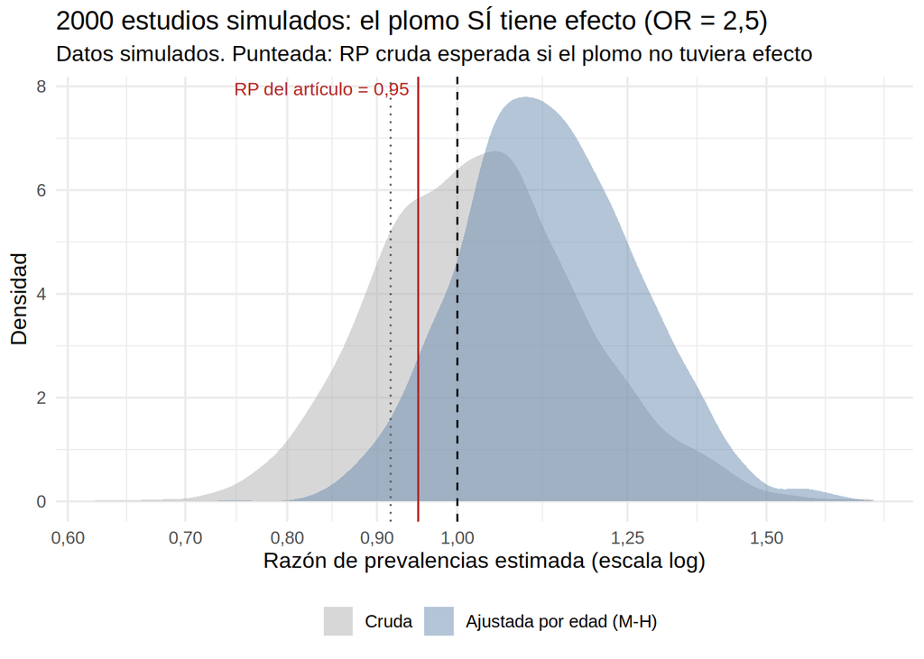

```r
datos_rep <- data.frame(
  rp = c(repeticiones[, "cruda"], repeticiones[, "ajustada"]),
  analisis = factor(rep(c("Cruda", "Ajustada por edad (M-H)"), each = nrow(repeticiones)),
                    levels = c("Cruda", "Ajustada por edad (M-H)"))
)
grafico_simulacion <- ggplot(datos_rep, aes(rp, fill = analisis)) +
  geom_density(alpha = 0.5, colour = NA) +
  geom_vline(xintercept = 1, linetype = "dashed") +
  geom_vline(xintercept = sesgo_edad$cruda[1], colour = "grey35", linetype = "dotted") +
  geom_vline(xintercept = 0.95, colour = "firebrick") +
  annotate("text", x = 0.95, y = Inf, label = "RP del artículo = 0,95",
           colour = "firebrick", hjust = 1.05, vjust = 1.5, size = 3.5) +
  scale_x_log10(breaks = c(0.6, 0.7, 0.8, 0.9, 1, 1.25, 1.5, 2),
                labels = function(x) format(x, decimal.mark = ",")) +
  scale_fill_manual(values = c("#b0b0b0", "#6a8caf"), name = NULL) +
  labs(x = "Razón de prevalencias estimada (escala log)", y = "Densidad",
       title = sprintf("%d estudios simulados: el plomo SÍ tiene efecto (OR = %s)",
                       n_rep, format(or_verdadero, decimal.mark = ",")),
       subtitle = "Datos simulados. Punteada: RP cruda esperada si el plomo no tuviera efecto") +
  theme_minimal(base_size = 12) +
  theme(legend.position = "bottom")
grafico_simulacion
```

**Interpretación.**

- **Sesgo esperado por la edad.** Si el plomo no tuviera ningún efecto, con la distribución de edad y plomo publicada la RP cruda esperada sería 0,92 y no 1. La edad empuja la RP cruda hacia abajo alrededor de un 8 %. La RP del artículo (0,95) está muy cerca de lo que se esperaría sin efecto.
- **Un efecto real quedaría escondido.** Con un efecto verdadero del plomo (OR = 2,5 dentro de cada edad), la RP ajustada esperada es 1,13, pero la cruda es solo 1,03. En los 2000 estudios simulados de 60 niños, la RP cruda quedó por debajo de 1 en el 41 % de los casos, aunque el plomo era dañino.
- **Magnitud.** Con estos datos el sesgo por edad es moderado. Por sí solo no convierte un efecto grande en nulo, pero sumado a la baja potencia (Parte 2) deja al estudio sin capacidad de distinguir “no hay efecto” de “hay un efecto pequeño o moderado enmascarado por la edad”. Hacía falta estratificar por edad o ajustar con un modelo (Mantel-Haenszel, Poisson robusta o regresión logística).

Hay además una duda sobre la medición. Que el Beery inferior aumente con la edad es lo contrario de lo esperado, y los propios autores sugieren que la prueba podría ser proporcionalmente más difícil para los mayores. Si las normas del test (edición de 1967) no clasifican igual a todas las edades, la relación entre edad y desenlace sería en parte un artefacto de la medición.

# Conclusiones

| Aspecto | Lo que hicieron | Lo que correspondía |
| --- | --- | --- |
| Diseño | “Analítico-ecológico” | Transversal analítico (datos individuales) |
| Análisis | t de Student sobre la media de plomo | RP con IC 95 % (desenlace según exposición) |
| P = 0,001 destacado | Pb-S ≥ 10 vs. < 10 (circular) | No informa sobre el desenlace |
| Sexo | “27 varones vs. 21 niñas” (conteos) | Proporciones: 77 % vs. 84 %, sin diferencia |
| Resultado | Sin medida de asociación | RP ≈ 0,95, IC incluye el 1 |
| Tamaño muestral | Fórmula para estimar una proporción (60) | Fórmula para comparar proporciones (164; 169 con grupos desiguales) |
| Confusión | Edad sin ajustar (sesgo esperado ≈ 8 %) | Estratificar por edad o regresión ajustada |

El problema principal del estudio no fue el diseño, sino el análisis y el control de la confusión. Un diseño de casos y controles no lo resolvía, porque el desenlace no es raro (80 %).